# LP2I2_Aula14_OrientacaoObjetos

[figure not shown]

Instituto Federal de São Paulo (IFSP)  
[Campus Bragança Paulista/SP](https://bra.ifsp.edu.br)  
**Análise e Desenvolvimento de Sistemas (ADS)**  
**2o. módulo**  
**Profa. Ana Paula Müller Giancoli**  
paulagiancoli@ifsp.edu.br

[figure not shown]

## AULA 14 - ORIENTAÇÃO A OBJETOS

### Agenda

- Introdução
  - Objetos, atributos, métodos, classes
  - Criando uma classe/Implementação
  - Criando uma instância
  - Chamando métodos
  - Criando várias instâncias
- Manipulando Classes, Instâncias, Atributos e Métodos
  - Trabalhando com Classes e Instâncias
  - Modificando Valores de Atributos
  - Conceitos de Herança
  - Utilizando os Conceitos de Herança
  - Manipulando Instâncias como atributos
- Importação de Classes e Módulos
- Conceitos de Modificadores e Encapsulamento
- Importante
- Perguntas

### 1. Introdução

### 1.1. Conceitos de Objetos, Atributos, Métodos, Classes

- **Objetos**: mundo real.
- **Atributos**: características.
- **Métodos**: comportamentos.
- **Classes**: agrupamento de objetos com as mesmas características e comportamentos.
- **Observação**: Para aprofundamento, consulte [Classes](https://docs.python.org/pt-br/3/tutorial/classes.html).

#### 1.1.1 Classe Aluno

```python
class Aluno:

    def __init__(self, prontuario, nome):
        self.prontuario = prontuario
        self.nome = nome

    def exibir(self):
        print(f"Prontuário: {self.prontuario} \nNome Completo: {self.nome}")


prontuario = input("Informe seu prontuário: ")
nomecompleto = input("Informe seu nome: ")
novoaluno = Aluno(prontuario, nomecompleto)
novoaluno.exibir()
```

```
Informe seu prontuário: 081401
Informe seu nome: Ana Paula Müller Giancoli
Prontuário: 081401
Nome Completo: Ana Paula Müller Giancoli
```

- Podemos modelar de tudo em classes.
- **Exemplo**: criaremos uma classe para representar cachorros, qualquer cachorro.
  - Um cachorro de estimação tem:
    - as seguintes características: nome e idade. Certo?
    - os seguintes comportamentos: sentar e rolar. Certo?
  - **Nome da Classe**: Cachorro
  - **Atributos**: nome, idade
  - **Métodos**: sentar( ), rolar( )
    - Essa **classe Cachorro** irá indicar ao Python que *para criar qualquer objeto que represente um cachorro, ela deverá ser usada*.
    - Logo, para **criarmos instâncias individuais**, utilizaremos esta **classe Cachorro** que representará *um cachorro específico a cada criação de uma instância*.

### 1.2. Criando uma Classe / Implementação - Cachorro( )

- **Colocando mão na massa!!!!**
  - **Classe Cachorro( )**: chamada de Cachorro que representa qualquer cachorro.
  - **Nomes com primeira letra maiúscula referem-se a classes em Python**.
  - """ texto """ as aspas triplas indicam nessa situação uma docstring utilizada para descrever o que a classe faz.
- Antes de declarar a classe, **deixar duas linhas em branco**. *Verifique o PEP de Estilos*.

```python
# Os textos entre aspas triplas são os docstring que indicam o que cada parte faz. E servirá como documentação.


class Cachorro:
    """Uma tentativa simples de modelar um cachorro"""

    def __init__(self, nome, idade):
        """Inicializa os atributos nome e idade"""
        self.nome = nome
        self.idade = idade

    def sentar(self):
        """Simula um cachorro sentando em resposta a um comando"""
        print(self.nome.title() + " está sentando.")

    def rolar(self):
        """Simula um cachorro rolando em resposta a um comando"""
        print(self.nome.title() + " está rolando!!")
```

- Comentando sobre o código acima:

#### **Método _**_init__**(self, nome, idade)**:

- Conceitualmente, **uma função** que faz parte de uma classe chama-se **método**.
- Tudo o que foi aprendido em **função aplica-se aos métodos**.
- Os **dois underscores antes e depois** servem para diferenciar **nomes default de Python** com os criados por nós.
- O **método _**_init__**(self)** é um **método especial do Python** que **é executado automaticamente sempre que uma instância é criada baseada na classe Cachorro**.
- O **método** recebe 3 parâmetros: **self, nome e idade**:
  - **self**: *é um parâmetro obrigatório na definição de um método e deve estar sempre antes dos demais parâmetros*.
    - Quando o Python chama o **método _**_init__**(self)** para criar uma instância de Cachorro, **a chamada passará o argumento self automaticamente**.
    - **Sempre que definir um método dentro de uma classe**, o mesmo deve receber como primeiro valor, o **self**.
    - Toda **chamada de método associada a uma classe passa o argumento self**.
    - O **argumento é uma referência à própria instância automaticamente**, permitindo acesso aos atributos e métodos da instância individual da classe.
  - *Não é preciso especificá-lo na chamada. É passado automaticamente por Python*.

### 1.3. Criando um instância a partir de uma classe Cachorro( )

- **Colocando mão na massa!!**
- **meu_cachorro** é a instância criada a partir da **classe Cachorro()**.
  - Acessando os **atributos nome e idade**: **meu_cachorro.nome**, **meu_cachorro.idade** .

```python
# Criando uma instancia com nome Willie e idade 10.
# meu_cachorro.nome.title() > title() permite o nome começar com letra maiúscula.
# str(meu_cachorro.idade) > converte para string o valor numérico de 10.
meu_cachorro = Cachorro('willie', 10)
print("O nome do meu cachorro é " + meu_cachorro.nome.title() + ".")
print("O meu cachorro tem " + str(meu_cachorro.idade) + " anos.")
```

```
O nome do meu cachorro é Willie.
O meu cachorro tem 10 anos.
```

### 1.4. Chamando Métodos de uma Instância criada meu_cachorro de uma classe Cachorro( )

- **Colocando mão na massa!!**
- Para executar ou chamar um método de uma instância, é necessário que o objeto da instância tenha sido criado, como no caso:
  - **meu_cachorro = Cachorro('willie', 10)** >> foi criado.
- **meu_cachorro** é a instância criada a partir da **classe Cachorro()**.
  - Acessando os **métodos sentar() e rolar()**: **meu_cachorro.sentar()**, **meu_cachorro.rolar()**.
  - Procura o **método sentar()** na **classe Cachorro()** e executa o código. E o **método rolar()** do mesmo jeito.

```python
# Acessando os métodos sentar() e rolar() da instância criada meu_cachorro.
meu_cachorro.sentar()
meu_cachorro.rolar()
```

```
Willie está sentando.
Willie está rolando!!
```

#### **Erro proposital**

- Trocando o nome do **método na classe Cachorro()** de **sentar()** para **setar()**.
  - Foi gerado um **erro proposital**, pois ao chamar o **método meu_cachorro.setar()** o mesmo não foi localizado.

```python
# Acessando os métodos sentar() e rolar() da instância criada meu_cachorro.
meu_cachorro.setar()
meu_cachorro.rolar()
print("O nome do meu cachorro é " + meu_cachorro.nome.title() + ".")
print("O meu cachorro tem " + str(meu_cachorro.idade) + " anos.")
```

```
---------------------------------------------------------------------------
AttributeError                            Traceback (most recent call last)
<ipython-input-5-fd9f43f9ccde> in <module>
      1 # Acessando os métodos sentar() e rolar() da instância criada meu_cachorro.
----> 2 meu_cachorro.setar()
      3 meu_cachorro.rolar()
      4 print("O nome do meu cachorro é " + meu_cachorro.nome.title() + ".")
      5 print("O meu cachorro tem " + str(meu_cachorro.idade) + " anos.")

AttributeError: 'Cachorro' object has no attribute 'setar'
```

### 1.5. Criando diversas Instâncias para a mesma Classe Cachorro( )

- **Colocando mão na massa!!**
  - **meu_cachorro** é a instância criada a partir da **classe Cachorro()**.
  - **seu_cachorro** é outra instância criada a partir da **classe Cachorro()**.
  - **dino_cao** é outra instância criada a partir da **classe Cachorro()**.

#### **Instância seu_cachorro**

```python
# Criando uma instancia com nome Lucy e idade 4.
# seu_cachorro.sentar() para a ação de sentar.
# seu_cachorro.rolar() para a ação de rolar.
seu_cachorro = Cachorro('lucy', 4)
seu_cachorro.sentar()
seu_cachorro.rolar()
print("O nome do meu cachorro é " + seu_cachorro.nome.title() + ".")
print("O meu cachorro tem " + str(seu_cachorro.idade) + " anos.")
```

```
Lucy está sentando.
Lucy está rolando!!
O nome do meu cachorro é Lucy.
O meu cachorro tem 4 anos.
```

#### **Instância dino_cao**

```python
# Criando uma instancia com nome Tobby e idade 3.
# dino_cao.sentar() para a ação de sentar.
# dino_cao.rolar() para a ação de rolar.
dino_cao = Cachorro('tobby', 3)
dino_cao.sentar()
dino_cao.rolar()
print("O nome do meu cachorro é " + dino_cao.nome.title() + ".")
print("O meu cachorro tem " + str(dino_cao.idade) + " anos.")
```

```
Tobby está sentando.
Tobby está rolando!!
O nome do meu cachorro é Tobby.
O meu cachorro tem 3 anos.
```

- **Observação**:
  - Mesmo que utilizássemos o **mesmo nome e a mesma idade** para o segundo cachorro Lucy, a linguagem Python criaria **uma instância separada da classe Cachorro( )**.
  - Podemos criar **tantas instâncias de uma classe quanto forem necessárias**, desde que dê a cada instância um nome de variável único ou que ela ocupe uma única posição em uma lista ou dicionário.

### 2. Manipulando Classes, Instâncias, Atributos, Métodos

### 2.1. Trabalhando com Classes e Instâncias

- Parte do nosso tempo utilizamos para criar, **modelar classes** do mundo real.
- Uma vez criada, nosso *foco muda* e passaremos maior parte do tempo **trabalhando com instâncias**.
- Criaremos uma **classe chamada de Carro**, conforme a definição a seguir:
  - **Nome da Classe**: Carro
  - **Atributos da Classe Carro**: fabricante, modelo, ano, leitura_hodometro
  - **Métodos da Classe Carro**: buscar_nome_descricao( ), ler_hodometro( ), atualizar_hodometro( ), incrementar_hodometro( ).

#### **Definição da Classe Carro, o método inicializador - conhecido como construtor - e as assinaturas de seus métodos.**

```python
class Carro:
    """Uma tentativa simples de representar um carro"""

    def __init__(self, fabricante, modelo, ano):
        """Inicializa os atributos que descrevem um carro. leitura_hodometro valor constante inicial"""
        self.fabricante = fabricante
        self.modelo = modelo
        self.ano = ano
        self.leitura_hodometro = 0  # atribuindo um valor default inicial = 0

# Definição da assinatura do método buscar_nome_descricao().
    def buscar_nome_descricao(self):

# Definição da assinatura do método ler_hodometro().
    def ler_hodometro(self):

# Definição da assinatura do método atualizar_hodometro().
    def atualizar_hodometro(self, milhas):

# Definição da assinatura do método incrementar_hodometro().
    def incrementar_hodometro(self, milhas):
```

#### Definindo o método buscar_nome_descricao( )

- Definição sem recebimento de parâmetro.

```python
class Carro:

    ...

    def buscar_nome_descricao(self):
        """Devolve um nome descritivo, em formato elegante :)"""
        nome_extenso = str(self.ano) + ' ' + self.fabricante + ' ' + self.modelo
        return nome_extenso.title()
```

#### Definindo o método ler_hodometro( )

- Definição sem recebimento de parâmetro.
- Efetua a leitura do valor default definido no construtor da classe Carro.

```python
class Carro:

    ...

    def ler_hodometro(self):
        """Exibe uma frase que mostra a milhagem do carro"""
        print("Esse carro tem " + str(self.leitura_hodometro) + " milhas.")
```

#### Definindo o método atualizar_hodometro( )

- Definição com recebimento de parâmetro: o valor de milhas a serem modificados no hodômetro.
- O método irá atualizar o valor 0 do atributo leitura_hodometro. Ou não, caso o valor informado seja menor do já registrado.
- Podemos **estender o método atualizar_hodometro( )** para que faça uma *tarefa adicional* sempre que a leitura do hodômetro for modificada.
- Vamos **sempre verificar**, assim poderemos garantir que **ninguém faça a redução do hodômetro**.

```python
class Carro:

    ...

    def atualizar_hodometro(self, milhas):
        """Define o valor de leitura do hodômetro com o valor especificado
           Rejeita a alteração se for uma tentativa de definir um valor menor
           para o hodômetro"""
        if milhas >= self.leitura_hodometro:
            self.leitura_hodometro = milhas
        else:
            print("Você está tentando reduzir o valor do Hodômetro!")
```

#### Definindo o método incrementar_hodometro( )

- Definição com recebimento de parâmetro: o valor de milhas a ser incrementado no valor default e posterior atualização.

```python
class Carro:

    ...

    def incrementar_hodometro(self, milhas):
        """"Soma a quantidade especificada ao valor de leitura do hodômetro"""
        if milhas > 0:
            self.leitura_hodometro += milhas
        else:
            print("Você está tentando reduzir o valor do Hodômetro!")
```

#### Classe Carro Completa:

```python
class Carro:
    """Uma tentativa simples de representar um carro"""

    def __init__(self, fabricante, modelo, ano):
        """Inicializa os atributos que descrevem um carro. leitura_hodometro valor constante inicial"""
        self.fabricante = fabricante
        self.modelo = modelo
        self.ano = ano
        self.leitura_hodometro = 0

    def buscar_nome_descricao(self):
        """Devolve um nome descritivo, em formato elegante :)"""
        nome_extenso = str(self.ano) + ' ' + self.fabricante + ' ' + self.modelo
        return nome_extenso.title()

    def ler_hodometro(self):
        """Exibe uma frase que mostra a milhagem do carro"""
        print("Esse carro tem " + str(self.leitura_hodometro) + " milhas.")

    def atualizar_hodometro(self, milhas):
        """Define o valor de leitura do hodômetro com o valor especificado
           Rejeita a alteração se for uma tentativa de definir um valor menor
           para o hodômetro"""
        if milhas >= self.leitura_hodometro:
            self.leitura_hodometro = milhas
        else:
            print("Você está tentando reduzir o valor do Hodômetro!")

    def incrementar_hodometro(self, milhas):
        """"Soma a quantidade especificada ao valor de leitura do hodômetro"""
        if milhas > 0:
            self.leitura_hodometro += milhas
        else:
            print("Você está tentando reduzir o valor do Hodômetro!")
```

#### Criando uma instância meu_novo_carro da classe Carro e testando seus métodos, atributos etc.

#### Método buscar_nome_descricao( )

```python
# Nova instância meu_novo_carro.
meu_novo_carro = Carro('audi', 'a4', 2018)

# Exibindo sua descrição.
print(meu_novo_carro.buscar_nome_descricao())
```

```
2018 Audi A4
```

#### Método ler_hodometro( )

- Não há necessidade de usar a **função print()** pois o método já efetua um **print()**.
- Chamando o método:

```python
meu_novo_carro.ler_hodometro()
```

```
Esse carro tem 0 milhas.
```

### 2.2. Modificando Valores de Atributos

#### 2.2.1. Atualizando o atributo leitura_hodometro com o valor de 23 milhas diretamente no Atributo

```python
# Exibindo sua descrição.
print(meu_novo_carro.buscar_nome_descricao())

# Lendo o valor atual do Hodometro.
meu_novo_carro.ler_hodometro()

# Atualizando o valor diretamente.
meu_novo_carro.leitura_hodometro = 23          # <-------

# Lendo o valor atual do Hodometro após a atribuição direta.
meu_novo_carro.ler_hodometro()
```

```
2018 Audi A4
Esse carro tem 0 milhas.
Esse carro tem 23 milhas.
```

#### 2.2.2. Atualizando o atributo leitura_hodometro com o valor de 33 milhas por meio do Método atualizar_hodometro( )

- Modificando o valor por meio do método atualizar_hodometro, passando o argumento 33 milhas.

```python
# Exibindo sua descrição.
print(meu_novo_carro.buscar_nome_descricao())

# Lendo o valor atual do Hodometro.
meu_novo_carro.ler_hodometro()

# Atualizando o valor por meio do método atualizar_hodometro().
meu_novo_carro.atualizar_hodometro(33)        # <-------

# Lendo o valor atual do Hodometro após a atualização pelo método.
meu_novo_carro.ler_hodometro()
```

```
2018 Audi A4
Esse carro tem 23 milhas.
Esse carro tem 33 milhas.
```

```python
# Simulando abaixar o valor do hodometro para 20 milhas por meio do método atualizar_hodometro().

# Exibindo sua descrição.
print(meu_novo_carro.buscar_nome_descricao())

# Lendo o valor atual do Hodometro.
meu_novo_carro.ler_hodometro()

# Atualizando o valor por meio do método atualizar_hodometro().
meu_novo_carro.atualizar_hodometro(20)        # <-------

# Lendo o valor atual do Hodometro após a atualização pelo método.
meu_novo_carro.ler_hodometro()
```

```
2018 Audi A4
Esse carro tem 33 milhas.
Você está tentando reduzir o valor do Hodômetro!
Esse carro tem 33 milhas.
```

#### 2.2.3. Atualizando o atributo leitura_hodometro com o valor de 100 milhas por meio do Método incrementar_hodometro( )

- Modificando o valor por meio do método incrementar_hodometro, passando o argumento 100 milhas.

```python
# Exibindo sua descrição.
print(meu_novo_carro.buscar_nome_descricao())

# Lendo o valor atual do Hodometro.
meu_novo_carro.ler_hodometro()

# Atualizando o valor por meio do método incrementar_hodometro().
meu_novo_carro.incrementar_hodometro(100)        # <-------

# Lendo o valor atual do Hodometro após a atualização pelo método.
meu_novo_carro.ler_hodometro()
```

```
2018 Audi A4
Esse carro tem 33 milhas.
Esse carro tem 133 milhas.
```

```python
# Simulando abaixar o valor do hodometro para -100 milhas por meio do método incrementar_hodometro().

# Exibindo sua descrição.
print(meu_novo_carro.buscar_nome_descricao())

# Lendo o valor atual do Hodometro.
meu_novo_carro.ler_hodometro()

# Atualizando o valor por meio do método incrementar_hodometro().
meu_novo_carro.incrementar_hodometro(-100)        # <-------

# Lendo o valor atual do Hodometro após a atualização pelo método.
meu_novo_carro.ler_hodometro()
```

```
2018 Audi A4
Esse carro tem 133 milhas.
Você está tentando reduzir o valor do Hodômetro!
Esse carro tem 133 milhas.
```

### Métodos mágicos

- Método **__str__(self)**:
  - É usado para retornar uma representação de string de um objeto.
- Método **__repr__(self)**:
  - É usado para retornar uma representação de um objeto e utilizado normalmente em debug para saber qual é o objeto que está sendo retornado.
- Se ambos estiverem no código, o Python entende que ao solicitar um print() do objeto, desejamos exibir para o usuário, logo, ele utilizará o **__str__**.

```python
# Imprimindo um objeto
# O método __str__ será usado para imprimir o objeto como uma string.
class Pessoa:


    def __init__(self, nome, idade):
        self.nome = nome
        self.idade = idade

    def __str__(self):
        return f'Pessoa {self.nome} com idade {self.idade}.'


nome_ana = Pessoa('Ana', 45)
print(nome_ana)
```

```
Pessoa Ana com idade 45.
```

```python
# Imprimindo um objeto
# O método __repr__ será usado para imprimir a representação de um objeto. Os símbolos de menor e maior serve
# para indicar aos programadores que será exibido um objeto daquela classe.
class Pessoa:


    def __init__(self, nome, idade):
        self.nome = nome
        self.idade = idade

    def __repr__(self):
        return f'<Pessoa({self.nome},{self.idade})>.'

nome_ana = Pessoa('Ana', 45)
print(nome_ana)
```

```
<Pessoa(Ana,45)>.
```

### 2.3. Conceitos de Herança

- Podemos utilizar as classes criadas, ou se quisermos criar uma classe especializada, por meio dos conceitos da **Herança**.
- **Quando uma classe herda de outra, ela assume automaticamente os seus atributos e métodos da classe original**, isto é *Herança*.
  - A **classe original** que passará seus atributos e métodos **chama-se classe-pai, classe-mãe, super classe**.
  - E a que **recebe**, é a **classe-filha, subclasse**. A **classe-filha** além de receber os atributos e métodos da **classe-pai**, ela **poderá também, definir seus próprios atributos e métodos**.
- **Exemplos Super Classe**: **Atenção**: Vamos usar a classe criada anteriormente.
  - **Nome da Classe**: Carro <---- É a **classe mãe, ou super classe**.
  - **Atributos da super classe**: fabricante, modelo, ano, leitura_hodometro.
  - **Métodos da super classe**: buscar_nome_descricao( ), ler_hodometro( ), atualizar_hodometro( ), incrementar_hodometro( ).
- **Exemplos Subclasse**:
  - **Nome da Classe**: CarroEletrico <---- É a **classe filha, ou subclasse**.
  - **Atributos da subclasse**: bateria que é do tipo de uma classe chamada Bateria.
  - **Métodos da subclasse**: abastecer_tanque( ), descricao_bateria( ).

### 2.3.1. Aplicando Herança

#### **Adicionando um novo método na classe mãe Carro: abastecer_tanque( ) e um novo atributo.**

```python
class Carro:
    """Uma tentativa simples de representar um carro"""

    def __init__(self, fabricante, modelo, ano):
        """Inicializa os atributos que descrevem um carro. leitura_hodometro valor constante inicial"""
        self.fabricante = fabricante
        self.modelo = modelo
        self.ano = ano
        self.leitura_hodometro = 0
        self.tanque = 0      #   <------ Criado para armazenar abastecimento do tanque. Default 0 litros.

    def buscar_nome_descricao(self):
        """Devolve um nome descritivo, em formato elegante :)"""
        nome_extenso = str(self.ano) + ' ' + self.fabricante + ' ' + self.modelo
        return nome_extenso.title()

    def ler_hodometro(self):
        """Exibe uma frase que mostra a milhagem do carro"""
        print("Esse carro tem " + str(self.leitura_hodometro) + " milhas.")

    def atualizar_hodometro(self, milhas):
        """Define o valor de leitura do hodômetro com o valor especificado
           Rejeita a alteração se for uma tentativa de definir um valor menor
           para o hodômetro"""
        if milhas >= self.leitura_hodometro:
            self.leitura_hodometro = milhas
        else:
            print("Você está tentando reduzir o valor do Hodômetro!")

    def incrementar_hodometro(self, milhas):
        """"Soma a quantidade especificada ao valor de leitura do hodômetro"""
        if milhas > 0:
            self.leitura_hodometro += milhas
        else:
            print("Você está tentando reduzir o valor do Hodômetro!")

# Método criado para abastecer o tanque do carro.
    def abastecer_tanque(self, tanque):
        self.tanque += tanque
        print("Tanque atualizado para " + str(self.tanque) + " litros.")
```

#### **Definição da Classe CarroEletrico e seus atributos especificos**

```python
# Definindo a classe filha, após a definição da classe mãe.
# A classe filha indica que é herdeira de quem, por meio do recebimento do argumento entre parênteses.
# Neste caso, recebe Carro, a classe mãe.
# O super().__init__(fabricante, modelo, ano) é usado pra indicar que o construtor da classe filha
# herda os atributos da classe mãe, sem necessidade de redefiní-los. Ao serem chamados executarão
# na classe mãe.

class CarroEletrico(Carro):
    """Representa aspectos de um carro específicos de veículos elétricos"""

    def __init__(self, fabricante, modelo, ano):
        """Inicializa os atributos da classe-mãe"""
        super().__init__(fabricante, modelo, ano)
        self.bateria = 70  # capacidade da bateria
```

#### Observações:

#### Classe Filha: CarroEletrico(Carro)

- **O arquivo inicia com a classe-mãe ---> Carro**.
- **As classes-filhas devem estar no mesmo arquivo da classe-mãe, após a sua definição**.
- **A classe CarroEletrico é definida após a classe Carro, sendo que a classe-filha recebe entre parênteses a classe-mãe**.

  **Função super( )**
  - O **método _**_init__**()** aceita as informações necessárias para **criar uma instância de Carro > fabricante, modelo, ano**.
  - Inserimos uma **função chamada super()**, a *qual é uma **função especial** que auxilia o Python a **criar conexões entre as classes-filhas e a classe-mãe***. Ao chamar a **função super()**, *indica que deve ser chamado o método* _**_init__**() da classe-mãe de CarroEletrico que confere os **atributos da classe-mãe**.
  - No Pycharm, ele indica do lado esquerdo, com um símbolo circular de que existe uma subclasse CarroEletrico.

#### **Observação**:

- Consulte [Real Python](https://realpython.com/python-super/) para maiores informações sobre a função .super().

#### **Definindo os métodos de CarroEletrico**

```python
class CarroEletrico(Carro):
    """Representa aspectos de um carro específicos de veículos elétricos"""

    def __init__(self, fabricante, modelo, ano):
        """Inicializa os atributos da classe-mãe"""
        super().__init__(fabricante, modelo, ano)
        self.bateria = 70       # capacidade da bateria

    def descricao_bateria(self):
        """Exibe uma frase que descreve a capacidade da bateria"""
        print("Esse carro tem " + str(self.bateria) + "-kWh de bateria.")
```

- Qualquer **método da classe-mãe** que por alguma configuração **não atender por completo a classe-filha**, o mesmo **pode ser sobrescrito**.
- Caso isso seja feito, ao executar, **o método a ser usado será o da classe-filha**.

#### Sobrescrevendo o método abastecer_tanque( )

- *Para que seja sobrescrito, na classe-filha, criar o método com mesmo nome da classe-mãe*.
- Imagine que temos um **método na classe-mãe que refere-se a controle do tanque de combustível (método abastecer_tanque()). Não faz sentido este método para o carro elétrico, logo poderíamos fazer algo do tipo na classe CarroEletrico**.

```python
class CarroEletrico(Carro):

...

    # Método criado igual ao da classe mãe. Assim o método da classe mãe será sobrescrito por esse.
    def abastecer_tanque(self):
        """Carros eletricos não possuem tanques"""
        print("Esse modelo de carro não possui tanque!")
```

### 2.3.2. Utilizando os Conceitos de Herança

- **Classe Carro Completa**

```python
class Carro:
    """Uma tentativa simples de representar um carro"""

    def __init__(self, fabricante, modelo, ano):
        """Inicializa os atributos que descrevem um carro. leitura_hodometro valor constante inicial"""
        self.fabricante = fabricante
        self.modelo = modelo
        self.ano = ano
        self.leitura_hodometro = 0
        self.tanque = 0      #   <------ Criado para armazenar abastecimento do tanque. Default 0 litros.

    def buscar_nome_descricao(self):
        """Devolve um nome descritivo, em formato elegante :)"""
        nome_extenso = str(self.ano) + ' ' + self.fabricante + ' ' + self.modelo
        return nome_extenso.title()

    def ler_hodometro(self):
        """Exibe uma frase que mostra a milhagem do carro"""
        print("Esse carro tem " + str(self.leitura_hodometro) + " milhas.")

    def atualizar_hodometro(self, milhas):
        """Define o valor de leitura do hodômetro com o valor especificado
           Rejeita a alteração se for uma tentativa de definir um valor menor
           para o hodômetro"""
        if milhas >= self.leitura_hodometro:
            self.leitura_hodometro = milhas
        else:
            print("Você está tentando reduzir o valor do Hodômetro!")

    def incrementar_hodometro(self, milhas):
        """"Soma a quantidade especificada ao valor de leitura do hodômetro"""
        if milhas > 0:
            self.leitura_hodometro += milhas
        else:
            print("Você está tentando reduzir o valor do Hodômetro!")

# Método criado para abastecer o tanque do carro.
    def abastecer_tanque(self, tanque):
        self.tanque += tanque
        print("Tanque atualizado para " + str(self.tanque) + " litros.")
```

- **Classe CarroEletrico Completa**

```python
class CarroEletrico(Carro):
    """Representa aspectos de um carro específicos de veículos elétricos"""

    def __init__(self, fabricante, modelo, ano):
        """Inicializa os atributos da classe-mãe"""
        super().__init__(fabricante, modelo, ano)
        self.bateria = 70       # capacidade da bateria

    def descricao_bateria(self):
        """Exibe uma frase que descreve a capacidade da bateria"""
        print("Esse carro tem " + str(self.bateria) + "-kWh de bateria.")

    # Método criado igual ao da classe mãe. Assim o método da classe mãe será sobrescrito por esse.
    def abastecer_tanque(self):
        """Carros eletricos não possuem tanques"""
        print("Esse modelo de carro não possui tanque!")
```

```python
# Criando uma nova instância de Carro e Carro Eletrico, acessando seus métodos.
meu_novo_carro_teste = Carro('Honda', 'New Civic', 2020)

# Exibindo sua descrição.
print(meu_novo_carro_teste.buscar_nome_descricao())

# Lendo o valor atual do Hodometro.
meu_novo_carro_teste.ler_hodometro()

# Atualizando o valor por meio do método atualizar_hodometro().
meu_novo_carro_teste.atualizar_hodometro(2000)

# Lendo o valor atual do Hodometro.
meu_novo_carro_teste.ler_hodometro()

# Atualizando o valor por meio do método atualizando o tanque.
meu_novo_carro_teste.abastecer_tanque(40)

# Criando uma instância do Carro Eletrico.
meu_eletrico = CarroEletrico('tesla', 'model s', 2016)

# Exibindo sua descrição.
print(meu_eletrico.buscar_nome_descricao())

# Exibindo a capacidade da bateria.
meu_eletrico.descricao_bateria()

# Abastecendo o tanque ??? Não é carro elétrico?
meu_eletrico.abastecer_tanque()
```

```
2020 Honda New Civic
Esse carro tem 0 milhas.
Esse carro tem 2000 milhas.
Tanque atualizado para 40 litros.
2016 Tesla Model S
Esse carro tem 70-kWh de bateria.
Esse modelo de carro não possui tanque!
```

### 2.3.3. Manipulando Instâncias como Atributos

- Se ao continuarmos implementando a classe CarroEletrico perceberemos que estamos inserindo atributos (tamanho da bateria) e métodos (descrição da bateria) que não são específicos dela e sim de outras classes.
- Logo, **precisamos criar uma classe Bateria** e **associá-la a classe CarroEletrico**.
- *Não é herança, é uma associação simples*.
- **Exemplos**:
  - **Nome da Classe**: CarroEletrico <---- É a **classe filha, ou subclasse**.
  - **Atributos da subclasse**: bateria que é do tipo de uma **classe chamada Bateria**.
  - **Métodos da subclasse**: abastecer_tanque( ), descricao_bateria( ).
- **Modificando a Classe CarroEletrico Completa para o atributo bateria do tipo classe Bateria.**

```python
class CarroEletrico(Carro):
    """Representa aspectos de um carro específicos de veículos elétricos"""

    def __init__(self, fabricante, modelo, ano):
        """Inicializa os atributos da classe-mãe"""
        super().__init__(fabricante, modelo, ano)
        self.bateria = Bateria()    #  <------- Modificado aqui de self.bateria = 70 para self.bateria = Bateria()

    # Método transferido para a devida classe Bateria
    #def descricao_bateria(self):
    #    """Exibe uma frase que descreve a capacidade da bateria"""
    #    print("Esse carro tem " + str(self.bateria) + "-kWh de bateria.")

    # Método criado igual ao da classe mãe. Assim o método da classe mãe será sobrescrito por esse.
    def abastecer_tanque(self):
        """Carros eletricos não possuem tanques"""
        print("Esse modelo de carro não possui tanque!")
```

- **Vamos criar a classe Bateria com os seguintes atributos: tamanho_bateria e métodos: descricao_bateria( ), buscar_faixa( )**.

```python
class Bateria:
    """Uma tentativa simples de modelar uma bateria para um carro elétrico"""


    def __init__(self, tamanho_bateria=70):
        self.tamanho_bateria = tamanho_bateria

    def descricao_bateria(self):
        """Exibe uma frase que descreve a capacidade da bateria"""
        print("Esse carro tem " + str(self.tamanho_bateria) + "-kWh de capacidade.")

    def buscar_faixa(self):
        """Exibe uma frase sobre a distância que o carro é capaz de percorrer
           de acordo com as especificações da bateria"""
        if self.tamanho_bateria == 70:
            range = 240
        elif self.tamanho_bateria == 85:
            range = 270

        message = "Esse carro pode percorrer aproximadamente " + str(range)
        message += " milhas com a bateria cheia."
        print(message)
```

#### Testando os métodos

```python
# Criando uma nova instância de Carro e Carro Eletrico, acessando seus métodos.
meu_novo_carro_teste = Carro('Honda', 'New Civic', 2020)

# Exibindo sua descrição.
print(meu_novo_carro_teste.buscar_nome_descricao())

# Lendo o valor atual do Hodometro.
meu_novo_carro_teste.ler_hodometro()

# Atualizando o valor por meio do método atualizar_hodometro().
meu_novo_carro_teste.atualizar_hodometro(2000)

# Lendo o valor atual do Hodometro.
meu_novo_carro_teste.ler_hodometro()

# Atualizando o valor por meio do método atualizando o tanque.
meu_novo_carro_teste.abastecer_tanque(40)

# Criando uma instância do Carro Eletrico.
meu_eletrico = CarroEletrico('tesla', 'model s', 2016)

# Exibindo sua descrição.
print(meu_eletrico.buscar_nome_descricao())

# Faixa da Bateria acessando o método buscar_faixa() por meio do atributo bateria do CarroEletrico.
meu_eletrico.bateria.buscar_faixa()

# Atualizando o valor da capacidade da bateria por meio do atributo bateria do CarroEletrico.
meu_eletrico.bateria.tamanho_bateria = 90

# Exibindo a capacidade da bateria. <----- Modificando a maneira de chamar meu_eletrico.descricao_bateria() para
# a chamada do método por meio da instância como atributo. Instância: meu_eletrico do tipo CarroEletrico,
# Atributo: bateria que é do tipo classe Bateria, logo, o método descrição_bateria() é acionado
# por meio do atributo.
meu_eletrico.bateria.descricao_bateria()      # <------------- LINHA 35

# Abastecendo o tanque ??? Não é carro elétrico?
meu_eletrico.abastecer_tanque()
```

```
2020 Honda New Civic
Esse carro tem 0 milhas.
Esse carro tem 2000 milhas.
Tanque atualizado para 40 litros.
2016 Tesla Model S
Esse carro pode percorrer aproximadamente 240 milhas com a bateria cheia.
Esse carro tem 90-kWh de capacidade.
Esse modelo de carro não possui tanque!
```

#### Analisando o código acima:

- A linha 35 indica ao Python para usar a **Instância meu_eletrico**, encontrar seu **Atributo bateria**, e chamar o **Método descricao_bateria( )** associado à **instância de Bateria armazenada no Atributo bateria**.

### Nota Importante

- Surgem novas funcionalidades, como consequência, arquivos maiores, mesmo quando utilizamos a herança de forma adequada.
- Seguindo a filosofia geral de Python, quanto menos entulhados estiverem os arquivos, melhor será.
- Python permite que as classes sejam **armazenadas em módulos e serem importadas em seu programa principal**. (Lembre da aula de [**LP2I2_Aula11_Modulos_Graficos_Pacotes**] para o Pycharm.)

### 2.3.4. Exemplo Herança Múltipla

- Consulte [Programiz](https://www.programiz.com/python-programming/methods/built-in/super)

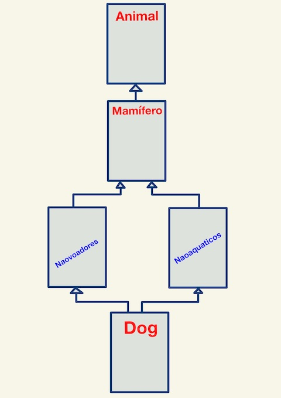

```python
class Animal:
    def __init__(self, animalnome):
        print(animalnome, 'é um animal.')


class Mamifero(Animal):
    def __init__(self, mamiferonome):
        print(mamiferonome, 'é um mamífero.')
        super().__init__(mamiferonome)


class Naovoadores(Mamifero):
    def __init__(self, naovoadoresnome):
        print(naovoadoresnome, "não pode voar.")
        super().__init__(naovoadoresnome)


class Naoaquaticos(Mamifero):
    def __init__(self, naoaquaticonome):
        print(naoaquaticonome, "não pode nadar.")
        super().__init__(naoaquaticonome)


class Dog(Naoaquaticos, Naovoadores):
    def __init__(self):
        print('Cachorro tem 4 patas.')
        super(Mamifero, self).__init__('Cachorro')


d = Dog()
print('')
morcego = Naoaquaticos('Morcego')
```

```
Cachorro tem 4 patas.
Cachorro é um animal.

Morcego não pode nadar.
Morcego é um mamífero.
Morcego é um animal.
```

### 3. Importação de Classes e Módulos

### 3.1. Importando Classes

- Vamos criar o **Módulo chamado carro.py** que conterá **todas as classes referentes a criação de um carro**.
- Em seguida, criaremos **um arquivo** que irá usar o **Módulo carro.py** para criar **uma instância de um carro elétrico** (meu_carro_eletrico.py) e **um comum** (meu_carro.py). (Neste caso faremos o código abaixo.)
- Criaremos também, **um outro arquivo chamado meus_carros.py** onde criaremos **uma instância de um carro elétrico e outro comum**.

```python
# Arquivo carro.py (módulo) contendo as 3 classes: Carro, CarroEletrico, Bateria.
# Todas as classes estão definidas e completas.

# classe Carro
class Carro:
    """Uma tentativa simples de representar um carro"""

    def __init__(self, fabricante, modelo, ano):
        """Inicializa os atributos que descrevem um carro. leitura_hodometro valor constante inicial"""
        self.fabricante = fabricante
        self.modelo = modelo
        self.ano = ano
        self.leitura_hodometro = 0
        self.tanque = 0      #   <------ Criado para armazenar abastecimento do tanque. Default 0 litros.

    def buscar_nome_descricao(self):
        """Devolve um nome descritivo, em formato elegante :)"""
        nome_extenso = str(self.ano) + ' ' + self.fabricante + ' ' + self.modelo
        return nome_extenso.title()

    def ler_hodometro(self):
        """Exibe uma frase que mostra a milhagem do carro"""
        print("Esse carro tem " + str(self.leitura_hodometro) + " milhas.")

    def atualizar_hodometro(self, milhas):
        """Define o valor de leitura do hodômetro com o valor especificado
           Rejeita a alteração se for uma tentativa de definir um valor menor
           para o hodômetro"""
        if milhas >= self.leitura_hodometro:
            self.leitura_hodometro = milhas
        else:
            print("Você está tentando reduzir o valor do Hodômetro!")

    def incrementar_hodometro(self, milhas):
        """"Soma a quantidade especificada ao valor de leitura do hodômetro"""
        if milhas > 0:
            self.leitura_hodometro += milhas
        else:
            print("Você está tentando reduzir o valor do Hodômetro!")

# Método criado para abastecer o tanque do carro.
    def abastecer_tanque(self, tanque):
        self.tanque += tanque
        print("Tanque atualizado para " + str(self.tanque) + " litros.")

# classe CarroEletrico que herda da classe Carro
class CarroEletrico(Carro):
    """Representa aspectos de um carro específicos de veículos elétricos"""

    def __init__(self, fabricante, modelo, ano):
        """Inicializa os atributos da classe-mãe"""
        super().__init__(fabricante, modelo, ano)
        self.bateria = Bateria()    #  <------- Modificado aqui de self.bateria = 70 para self.bateria = Bateria()


    # Método criado igual ao da classe mãe. Assim o método da classe mãe será sobrescrito por esse.
    def abastecer_tanque(self):
        """Carros eletricos não possuem tanques"""
        print("Esse modelo de carro não possui tanque!")

# classe Bateria que é associada a Classe CarroEletrico por meio do atributo self.bateria que
# é do tipo da classe Bateria()
class Bateria:
    """Uma tentativa simples de modelar uma bateria para um carro elétrico"""


    def __init__(self, tamanho_bateria=70):
        self.tamanho_bateria = tamanho_bateria

    def descricao_bateria(self):
        """Exibe uma frase que descreve a capacidade da bateria"""
        print("Esse carro tem " + str(self.tamanho_bateria) + "-kWh de capacidade.")

    def buscar_faixa(self):
        """Exibe uma frase sobre a distância que o carro é capaz de percorrer
           de acordo com as especificações da bateria"""
        if self.tamanho_bateria == 70:
            range = 240
        elif self.tamanho_bateria == 85:
            range = 270

        message = "Esse carro pode percorrer aproximadamente " + str(range)
        message += " milhas com a bateria cheia."
        print(message)
```

```python
# Criado o módulo (arquivo) carro.py contendo as 3 classes, criar o arquivo meu_carro.py.
# Arquivo meu_carro.py.

# Importando o módulo carro.py.
from carro import Carro

# Criando uma nova instância.
meu_novo_carro = Carro('Suzuki', 'Jimny', 2020)

# Exibindo a descrição deste nova instância.
print(meu_novo_carro.buscar_nome_descricao())

# Alterando a leitura do Hodometro.
meu_novo_carro.leitura_hodometro = 55

# Lendo o Hodometro.
meu_novo_carro.ler_hodometro()

# Atualizando o valor por meio do método atualizando o tanque.
meu_novo_carro.abastecer_tanque(40)
```

```
2020 Suzuki Jimny
Esse carro tem 55 milhas.
Tanque atualizado para 40 litros.
```

```python
# Criado o módulo (arquivo) carro.py contendo as 3 classes, criar o arquivo meu_carro_eletrico.py.
# Arquivo meu_carro_eletrico.py.

# Importando o módulo carro.py.
from carro import CarroEletrico

# Criando uma nova instância.
meu_novo_carro_eletrico = CarroEletrico('tesla', 'model s', 2020)

# Exibindo a descrição deste nova instância.
print(meu_novo_carro_eletrico.buscar_nome_descricao())

# Faixa da Bateria acessando o método buscar_faixa() por meio do atributo bateria do CarroEletrico.
meu_novo_carro_eletrico.bateria.buscar_faixa()

# Atualizando o valor da capacidade da bateria por meio do atributo bateria do CarroEletrico.
meu_novo_carro_eletrico.bateria.tamanho_bateria = 30
meu_novo_carro_eletrico.bateria.descricao_bateria()

# Alterando a leitura do Hodometro.
meu_novo_carro_eletrico.leitura_hodometro = 885

# Lendo o Hodometro.
meu_novo_carro_eletrico.ler_hodometro()

# Atualizando o valor por meio do método atualizando o tanque.
meu_novo_carro_eletrico.abastecer_tanque()
```

```
2020 Tesla Model S
Esse carro pode percorrer aproximadamente 240 milhas com a bateria cheia.
Esse carro tem 30-kWh de capacidade.
Esse carro tem 885 milhas.
Esse modelo de carro não possui tanque!
```

### 3.2. Importando Módulos

- Neste caso, importaremos o **Módulo carro.py**, e utilizaremos o **ponto para acessar** o que for preciso **dentro deste módulo**.

  ```
  <nomeMódulo.nomeClasse>
  ```

```python
# Criado o módulo (arquivo) carro.py contendo as 3 classes, criar o arquivo meus_carros.py.
# Arquivo meus_carros.py.

# Importando o módulo carro.py.
from carro import Carro, CarroEletrico
import carro

print(30 * '*')
print('Carro')

# Criando uma nova instância.
meu_bee = carro.Carro('volkswagen', 'beetle', 2020)

# Exibindo a descrição deste nova instância.
print(meu_bee.buscar_nome_descricao())

# Incrementando o hodometro
meu_bee.incrementar_hodometro(2000)

# Lendo o Hodometro.
meu_bee.ler_hodometro()

# Atualizando o valor por meio do método atualizando o tanque.
meu_bee.abastecer_tanque(40)

print(30 * '*')
print('Carro Elétrico')

# Criando uma nova instância.
meu_tesla = carro.CarroEletrico('tesla', 'roadster', 2020)

# Exibindo a descrição deste nova instância.
print(meu_tesla.buscar_nome_descricao())

# Incrementando o hodometro
meu_tesla.incrementar_hodometro(2000)

# Lendo o Hodometro.
meu_tesla.ler_hodometro()

# Atualizando o valor por meio do método atualizando o tanque.
meu_tesla.abastecer_tanque()

# Buscando faixa bateria
meu_tesla.bateria.buscar_faixa()

print(30 * '*')
```

[output not shown]

### 3.2.1. Importando todas as classes de um Módulo

- Neste caso, importaremos do **Módulo carro** com todas as classe da seguinte forma.
- **Sintaxe**:

  ```
  from <nomeMódulo> import *.
  ```

- Esse **método não é recomendado**.
- *Com essa abordagem não fica claro quais classes estão sendo utilizadas e também, poderá gerar confusão de nomes usados nos arquivos. Poderá importar o mesmo nome de outro arquivo etc*.

### 4. Conceitos de Modificadores e Encapsulamento

#### **Fracamente**

- O Python não utiliza o **termo private**, que é **um modificador de acesso** e também chamado de **modificador de visibilidade**.
- Existe uma **convenção**:
  - **Métodos e atributos fracamente privados** *são os que possuem um **underscore antes do nome***. Essa abordagem **apenas sinaliza que essas variáveis são privadas e outros programadores não devem utilizá-las em código externos**.
  - Nessa situação **conseguimos fazer o acesso de *fora* da classe**.

#### **Encapsulamento**

- **Encapsular é fundamental** para que seu sistema seja suscetível a mudanças:
  - não precisamos mudar uma regra de negócio em vários lugares, mas sim em apenas um único lugar, já que essa regra está encapsulada.
  - Quando utilizamos os **underscores estamos alertando para não ler diretamente** aquele atributo ou mesmo modificá-lo diretamente. Para isso, **utilizar os métodos de acesso get e set**.
  - Aprofunde o assunto, lendo [Prof. Marcolan](https://professormarcolan.com.br/encapsulamento-em-python/).

```python
# Exemplo
class Pessoa:

    def __init__(self, nome, idade):
        """Inicializa os atributos que descrevem uma pessoa."""
        self.nome = nome
        self.idade = idade

    def get_nome(self):
        return self.nome

    def get_idade(self):
        return self.idade

nova_pessoa = Pessoa('Carlos Alberto', 80)
print(nova_pessoa.nome)
print(nova_pessoa.idade)
print(nova_pessoa.get_idade())
```

```
Carlos Alberto
80
80
```

```python
# Exemplo
class Pessoa:

    def __init__(self, nome, idade):
        """Inicializa os atributos que descrevem uma pessoa."""
        self.nome = nome
        self._idade = idade        # <------ Inserido um underscore para indicar atributo fracamente privado.

    def get_nome(self):
        return self.nome

    def get_idade(self):
        return self._idade          # <------ Retornando um atributo fracamente privado.

nova_pessoa = Pessoa('Carlos Alberto', 80)
print(nova_pessoa.nome)
print(nova_pessoa._idade)           # <------ Exibindo um atributo fracamente privado.
print(nova_pessoa.get_idade())      # <------ Exibindo um atributo fracamente privado por meio do método get().
```

```
Carlos Alberto
80
80
```

#### **Fortemente**

- **Métodos e atributos fortemente privados** são os que **possuem duplo underscore antes do nome**. Essa abordagem **sinaliza que essas variáveis são privadas. Não é possível acessá-los de forma padrão**.
- Para isso, fazemos o **acesso de fora da classe por**: **nomeInstância._nomeClasse__nomeatributo**. (primeiro é usado um underscore antes do nome da classe, e em seguinda, dois underscores antes do nome do atributo).
- As mesmas regras de acesso aos atributos valem para os **métodos**.

```python
# Exemplo
class Pessoa:

    def __init__(self, nome, idade):
        """Inicializa os atributos que descrevem uma pessoa."""
        self.nome = nome
        self.__idade = idade        # <------ Inserido dois underscore para indicar atributo fortemente privado.

nova_pessoa = Pessoa('Carlos Alberto', 80)
print(nova_pessoa.nome)
print(nova_pessoa.__idade)           # <------ Exibindo um atributo fortemente privado.
```

```
Carlos Alberto
```

```
---------------------------------------------------------------------------
AttributeError                            Traceback (most recent call last)
<ipython-input-31-02a803e24fe8> in <module>
      9 nova_pessoa = Pessoa('Carlos Alberto', 80)
     10 print(nova_pessoa.nome)
---> 11 print(nova_pessoa.__idade)           # <------ Exibindo um atributo fortemente privado.

AttributeError: 'Pessoa' object has no attribute '__idade'
```

```python
# Exemplo
class Pessoa:

    def __init__(self, nome, idade):
        """Inicializa os atributos que descrevem uma pessoa."""
        self.nome = nome
        self.__idade = idade        # <------ Inserido um underscore para indicar atributo fortemente privado.

    def get_nome(self):
        return self.nome

    def get_idade(self):
        return self.__idade          # <------ Retornando um atributo fortemente privado.

nova_pessoa = Pessoa('Carlos Alberto', 80)
print(nova_pessoa.nome)
print(f'Idade = {nova_pessoa.get_idade()}.')           # <------ Exibindo um atributo fortemente privado.
print(nova_pessoa._Pessoa__idade)      # <------ Exibindo um atributo fortemente privado por meio da classe.
```

```
Carlos Alberto
Idade = 80.
80
```

### 5. Importante

- **Python são multi-paradigmas**, você pode escrever programas ou bibliotecas amplamente procedurais, orientadas a objetos ou funcionais. Depende do que você entende por funcional. Python tem alguns recursos de uma linguagem funcional.
- Os conceitos de programação orientada a objetos: como Classes, Encapsulamento, Herança etc. no Python o tornam uma linguagem de programação orientada a objetos.
- **Tudo em Python é um objeto**.
- **Todos os conceitos adquiridos até o momento são aplicados em ambos paradigmas**.
- Mais informações: [Caelum](https://www.caelum.com.br/apostila-python-orientacao-objetos/o-que-e-python/)

### Exercícios para resolver em sala em duplas

- **Exercício1 - Restaurante**:
  - Utilizando os conceitos adquiridos na aula de hoje, crie uma **classe chamada Restaurante**.
  - O método init () de Restaurante deve armazenar dois atributos: nome_restaurante e tipo_cozinha.
  - Crie um **método chamado descricao_restaurante()** que mostre essas **duas informações** e um **método de nome abertura_restaurante()** que exiba uma mensagem informando que o **restaurante está aberto**.
  - *Crie uma instância chamada restaurante a partir de sua classe. Mostre os dois atributos individualmente e em seguida, chame os dois métodos*.
  - Entregue sua atividade no moodle, no link apropriado.
- **Exercício2 - Restaurante**:
  - A partir da classe criada no Exercício1, crie 3 instâncias diferentes da classe e chame o método descricao_restaurante() para cada instância.
- **Exercício3 - Usuários**:
  - Crie uma classe chamada Usuario.
  - Crie dois atributos de nomes primeiro_nome e ultimo_nome e, crie outros atributos normalmente armazenados em um perfil de usuário.
  - Escreva um método de nome descricao_usuario() que apresente um resumo das informações do usuário.
  - Escreva outro método chamado greet_usuario que mostre uma saudação personalizada ao usuário.
  - Crie diversas instâncias que representem diferentes usuários e chame os dois métodos para cada instância.
- **Exercício4 - Pessoas Atendidas**:
  - A partir do Exercício1, acrescente na classe chamada Restaurante, o atributo pessoas_atendidas cujo valor default é 0.
  - Crie um instância chamada restaurante a partir desta classe, apresente o número de cliente atendidos pelo restaurante e, em seguida, mude esse valor e exiba-o novamente.
  - Acrescente um método chamado set_pessoas_atendidas() que permita definir o número de clientes atendidos. Chame este método com um novo número e mostre o valor novamente.
  - Adicione um método chamado incrementar_pessoas_atendidas() que permita incrementar o número de clientes servidos. Chame esse método com qualquer número que você quiser e que represente quantos clientes foram atendidos, por exemplo, em um dia de funcionamento.
- **Exercício5 - Tentativas de Login**:
  - A partir do Exercício3, acrescente um atributo tentativas_login à sua classe Usuario.
  - Escreva um método chamado incrementar_tentativas_login() que incremente o valor do atributo tentativas_login.
  - Escreva outro método chamado reset_tentativas_login() que reinicie o valor de tentativas_login.
- **Exercício6 - Tentativas de Login**:
  - Crie uma instância de Usuario e chame incrementar_tentativas_login() várias vezes. Exiba o valor de tentativas_login para garantir que ele foi incrementado de forma apropriada e, em seguida, chame o reset_tentativas_login().
  - Exiba tentativas_login novamente para garantir que seu valor foi reiniciado com 0.
- **Mais exercícios**, consulte [Wiki](https://wiki.python.org.br/ExerciciosClasses)

### Referências

- Esta aula foi elaborada a partir do conteúdo disponibilizado no [Python Dev](https://www.python.org/dev/) e [Site Oficial](https://docs.python.org/3/).
- [Matthes, Eric]. Curso Intensivo de Python - Uma introdução prática e baseada em projetos à programação. Editora Novatec. Reimpressão Fevereiro/2019.
- [Caelum](https://www.caelum.com.br/apostila-python-orientacao-objetos/encapsulamento/). Capítulo 8. Modificadores de acesso e métodos de classe. Acesso em: 23 jun. 2020.

### Perguntas

- Esclareça suas eventuais dúvidas durante as aulas.
- Ou pelo *E-mail*: paulagiancoli@ifsp.edu.br.
- Ou pelo *Fórum* do componente curricular.
- Ou acesse [Github Ana Giancoli](https://anagiancoli.github.io) e solicite atendimento para o componente curricular.

*ADS - Python versão 3.7 - 2o. módulo*.  
Modelo e formato elaborado por profa. Ana Paula Müller Giancoli - BSD 2-Clause License. - Julho.2020.